# project_1

Salma Elshahawy

2021-04-11

[Github repo](https://github.com/salma71/MSDS_spring2021/tree/master/data_624) | [portfolio](https://salma71.github.io/) | [Blog](https://salmaeng71.medium.com/)

## Part A – ATM Forecast, ATM624Data.xlsx

[The generated forcates are on Github](https://github.com/salma71/MSDS_spring2021/blob/master/data_624/ATM_Forecasts.xlsx)

In part A, I want you to forecast how much cash is taken out of 4 different ATM machines for May 2010. The data is given in a single file. The variable ‘Cash’ is provided in hundreds of dollars, other than that it is straight forward. I am being somewhat ambiguous on purpose to make this have a little more business feeling. Explain and demonstrate your process, techniques used and not used, and your actual forecast. I am giving you data via an excel file, please provide your written report on your findings, visuals, discussion and your R code via an RPubs link along with the actual.rmd file Also please submit the forecast which you will put in an Excel readable file.

## Introduction

For this part, we need to forecast how much cash will be taken out of 4 different ATM machines for May 2010.  
Data was provided for this project. The cash is in hundreds of dollars.

## Data Exploration

I will begin by plotting the cash withdrawn by each ATM.

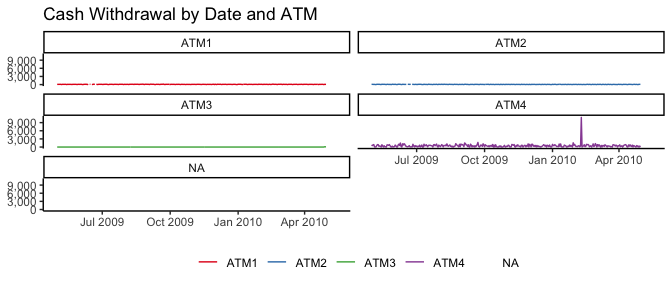

ATM4 was used at a higher rate than every other ATM in the data series. There is an unusual spike in ATM4. There are some missing ATM labels in the data. Let’s remove ATM4 and the missing label from the dataset and replot the visualization:

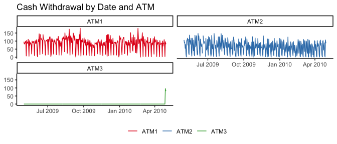

It seems that ATM3 was not used until recently. ATM #1 and #2 seem similar to each other. It doesn’t seem like there is much of a trend in the data. Let’s explore the distributions further:

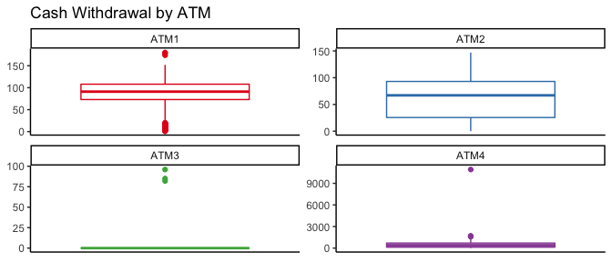

| ATM | Minimum | 1st Qu. | Mean | Median | 3rd Qu. | Maximum | NA’s |
| --- | --- | --- | --- | --- | --- | --- | --- |
| ATM1 | 1.00000 | 73.0000 | 83.8867403 | 91.0000 | 108.000 | 180.00 | 3 |
| ATM2 | 0.00000 | 25.5000 | 62.5785124 | 67.0000 | 93.000 | 147.00 | 2 |
| ATM3 | 0.00000 | 0.0000 | 0.7205479 | 0.0000 | 0.000 | 96.00 | 0 |
| ATM4 | 1.56326 | 124.3344 | 474.0433449 | 403.8393 | 704.507 | 10919.76 | 0 |

There is a pattern in the time series but fluctuations are very tight. I wonder if it is explained by the day of the week. For example, Friday and Saturday might have heavier usage and a Tuesday night might be calm. Let’s examine this hypothesis:

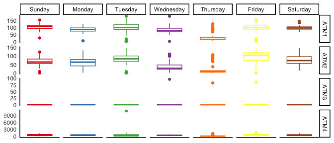

It looks like there is some varriation based on the day of the week. Thursday looks to be less busy than the other days of the week. There is so much variation between the 4 ATMs that each will be modeled separately.

We will clean up the data to produce the forecasts. Then explore some candidate modeling techniques. Once we have a handful of candidates, we will prefrom a cross-validation on the models and get the RMSE. The model that minimizes the RMSE during cross-validation will be selected as the model of choice.

### ATM_1

#### Data Cleanup

There are 3 missing observations that need to be cleaned up.

Now that we have a complete data set I will create time series objects. Since there is a weekly effect I will be using a frequency of 7. This does mess up the dates in the plot however so please pay no reguard to them.

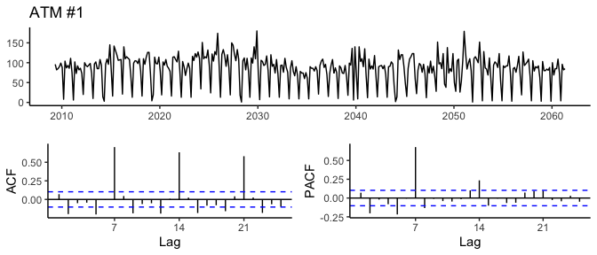

One readily observes the repeating peaks on every 7th lag. There also seems to be an interesting negative correlation between the 1st and both the 3rd and the 5th lag.

### Model Creation

#### STL Decomposition Models

I will try a couple of seasonal decomposition models. I will set the seasonal window to 7 so it picks up the day of the week variation.

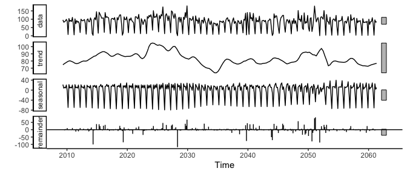

This seems promising to me. I will do STL decomposition forecasts using both the ETS and ARIMA models and check their residual plots

#### STL + ETS

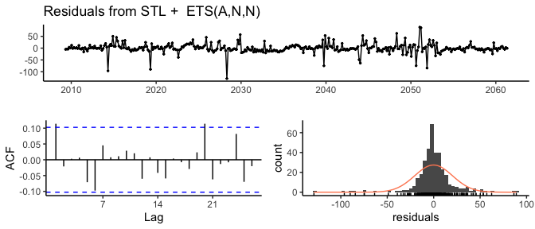

```
#>
#>  Ljung-Box test
#>
#> data:  Residuals from STL +  ETS(A,N,N)
#> Q* = 13.759, df = 12, p-value = 0.3164
#>
#> Model df: 2.   Total lags used: 14
```

This model seems to hold merit and should be taken under consideration.

#### STL + ARIMA

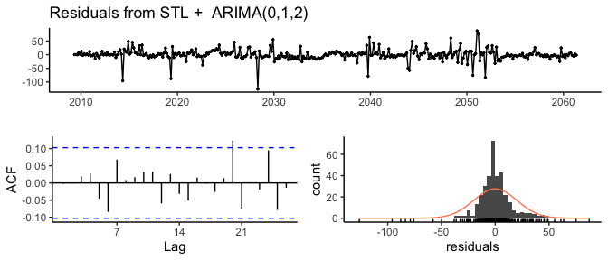

```
#>
#>  Ljung-Box test
#>
#> data:  Residuals from STL +  ARIMA(0,1,2)
#> Q* = 8.4479, df = 12, p-value = 0.7492
#>
#> Model df: 2.   Total lags used: 14
```

This model also preformed well. It is definately a candidate for the cross-validation stage.

#### Holt-Winters

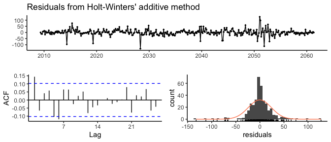

```
#>
#>  Ljung-Box test
#>
#> data:  Residuals from Holt-Winters' additive method
#> Q* = 28.877, df = 3, p-value = 2.376e-06
#>
#> Model df: 11.   Total lags used: 14
```

This method did a fairly good job. I will move it on to the next phase.

### Holt-Winters with Box Cox Adjustment

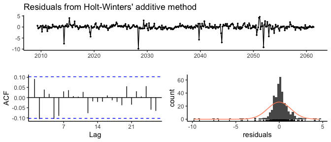

```
#>
#>  Ljung-Box test
#>
#> data:  Residuals from Holt-Winters' additive method
#> Q* = 18.824, df = 3, p-value = 0.0002973
#>
#> Model df: 11.   Total lags used: 14
```

This seems to be a strong candidate. We will see how if fares in the cross-validation.

#### ARIMA

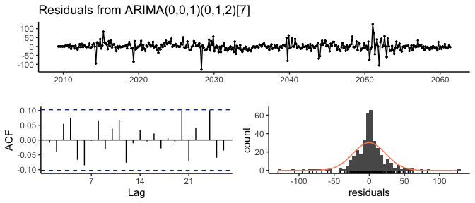

```
#>
#>  Ljung-Box test
#>
#> data:  Residuals from ARIMA(0,0,1)(0,1,2)[7]
#> Q* = 15.247, df = 11, p-value = 0.1715
#>
#> Model df: 3.   Total lags used: 14
```

This model looks like it is preforming well. Let’s see how all of them stack up.

### Cross Validation

In order to understand how well a model is likely to preform at predicting out of sample data, I will use the `tsCV` function and evaluate the models. As prevously noted my goal is to minimize the RMSE. First I will get the errors from the cross validation process, then I will compute the RMSE.

| Model | RMSE |
| --- | --- |
| ARIMA | 29.67002 |
| STL ARIMA | 31.80636 |
| STL ETS | 31.81959 |
| Adjusted Holt-Winters | 34.30067 |
| Holt-Winters | 39.49958 |

It looks like the ARIMA model perform good job predicting on the out of sample data set.

### Model Selection

The ARIMA model would be selected to produce the forecast for ATM #1. This because it is the model has more generalization and robustness across the cross validation.

### ATM 2

We will repeat the same process for ATM 2, then select the most generalized robust model using the cross validation.

### Data Cleanup

There are 2 missing observations. This will be cleaned up using the `tsclean` function again.

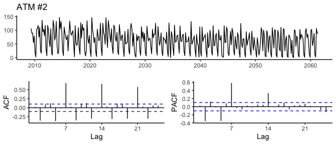

Once again the ACF plot has the regular spikes on evry multiple of 7.

### Model Creation

#### STL Decomposition Models

Again I will try a couple of seasonal decomposition models. I will set the seasonal window to 7 so it picks up the day of the week variation.

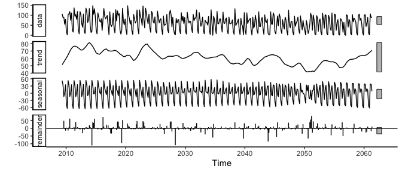

This seems very similar to ATM #1.

#### STL + ETS

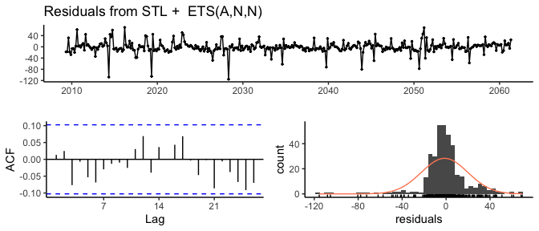

```
#>
#>  Ljung-Box test
#>
#> data:  Residuals from STL +  ETS(A,N,N)
#> Q* = 9.2372, df = 12, p-value = 0.6825
#>
#> Model df: 2.   Total lags used: 14
```

This model preformed much better than the it did for the ATM #1 time series. It will be interesting to see how it does in cross-validation

#### STL + ARIMA

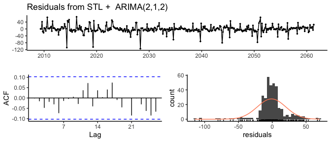

```
#>
#>  Ljung-Box test
#>
#> data:  Residuals from STL +  ARIMA(2,1,2)
#> Q* = 7.4932, df = 10, p-value = 0.6782
#>
#> Model df: 4.   Total lags used: 14
```

Interesting. The residuals have a bit more spread but the left tail is shorter than the STL+ETS model.

#### Holt-Winters

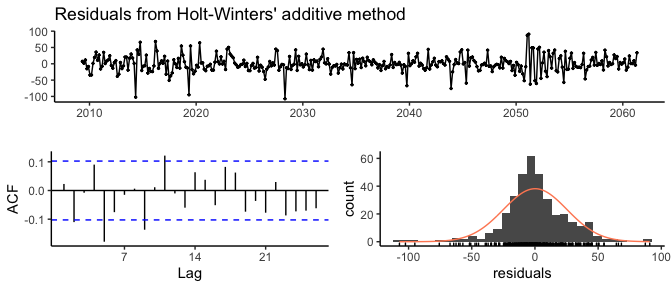

```
#>
#>  Ljung-Box test
#>
#> data:  Residuals from Holt-Winters' additive method
#> Q* = 37.435, df = 3, p-value = 3.722e-08
#>
#> Model df: 11.   Total lags used: 14
```

This method did not preform as well as the others. I will, however keep it in so I can compare it to ATM #1’s statistics.

### Holt-Winters with Box Cox Adjustment

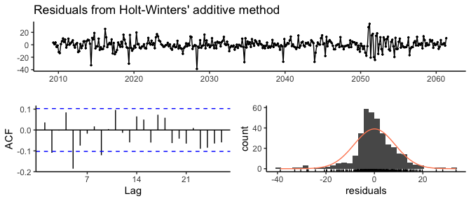

```
#>
#>  Ljung-Box test
#>
#> data:  Residuals from Holt-Winters' additive method
#> Q* = 34.776, df = 3, p-value = 1.358e-07
#>
#> Model df: 11.   Total lags used: 14
```

#### ARIMA

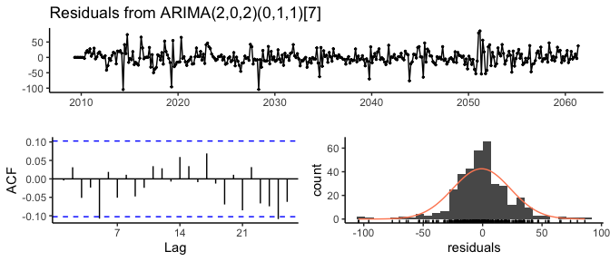

```
#>
#>  Ljung-Box test
#>
#> data:  Residuals from ARIMA(2,0,2)(0,1,1)[7]
#> Q* = 10.231, df = 9, p-value = 0.3321
#>
#> Model df: 5.   Total lags used: 14
```

This model looks like it is preforming well. Let’s see how all of them stack up.

### Cross Validation

In order to understand how well a model is likely to preform at predicting out of sample data, I will use the `tsCV` function and evaluate the models. As previously noted my goal is to minimize the RMSE. First I will get the errors from the cross validation process, then I will compute the RMSE.

| Model | RMSE |
| --- | --- |
| ARIMA | 33.52037 |
| STL ARIMA | 34.17286 |
| STL ETS | 34.96679 |
| Adjusted Holt-Winters | 41.53970 |
| Holt-Winters | 55.33134 |

Interesting. It looks like the ARIMA model was the top preformer again. I find it interesting that the RMSE is higher and more spread out for ATM #2. ATM #1’s RMSEs ranged from roughly ~ 30 to 39. The RMSEs for ATM #2 ranged from ~ 33 to 55. There is more variability in this data that isn’t captured by the model.

### Model Selection

As stated in the previous section I will use the ARIMA model to produce the forecast for ATM #2.

## ATM #3

This model is quite different from the two proceeding cases. You can see it in the plot:

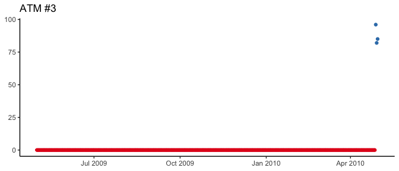

Most of the values are zeros (points in red above), except for 3 points (shown in blue). The three non-zero points are the most current. This presents a serious challenge.

### Model Creation/Selection

There is one fundamental question with this dataset. Are the three points an outlier, or is it the begining of the new normal? If they are outliers one would expect the cash value to return to zero. If the three points are an indication of change, then the historical data have little relevance.

I will be assuming the new data are the begining of the new normal. The challenge is we only have three data points. In the absense of more data I will calculate the average of these three points and use it for the forecast with the recommendation to revise it frequently. As the average is only based off of three data points it should not be considered stable.

## ATM #4

This ATM is different too, but not as radically different as ATM #3. I will be using the same approach used for ATM #1 and #2 with this ATM.

### Data Cleanup

There is one major outlier in the data set. We will clean it up by simply by using the `tsclean` function once again.

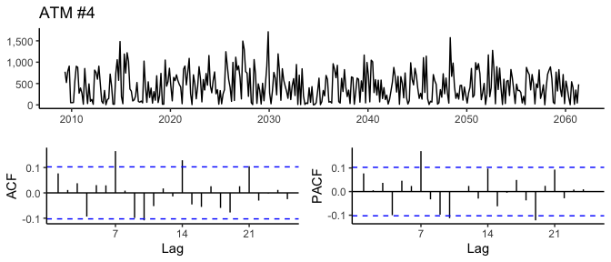

Once again there is the familiar patter of peaks on the multiples of seven.

### Model Creation

#### STL Decomposition Models

Again I will try a couple of seasonal decomposition models. I will set the seasonal window to 7 so it picks up the day of the week variation.

[figure not shown]

#### STL + ETS

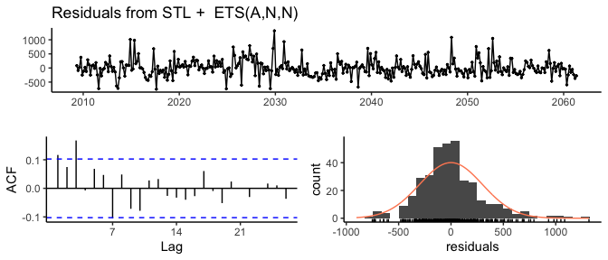

```
#>
#>  Ljung-Box test
#>
#> data:  Residuals from STL +  ETS(A,N,N)
#> Q* = 30.61, df = 12, p-value = 0.002258
#>
#> Model df: 2.   Total lags used: 14
```

This model did a fair job. There are a couple of ACF spikes that are outside the bands. Let’s see if the ARIMA model does better:

#### STL + ARIMA

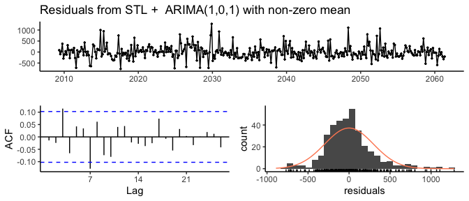

```
#>
#>  Ljung-Box test
#>
#> data:  Residuals from STL +  ARIMA(1,0,1) with non-zero mean
#> Q* = 21.78, df = 11, p-value = 0.02614
#>
#> Model df: 3.   Total lags used: 14
```

This is an improvement over the STL+ETS model. There are still a couple of spikes on the ACF that falls outside the threshold.

#### Holt-Winters

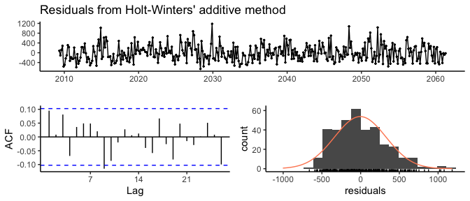

```
#>
#>  Ljung-Box test
#>
#> data:  Residuals from Holt-Winters' additive method
#> Q* = 18.279, df = 3, p-value = 0.0003852
#>
#> Model df: 11.   Total lags used: 14
```

This method seems to have preformed better than any of the STL models.

### Holt-Winters with Box Cox Adjustment

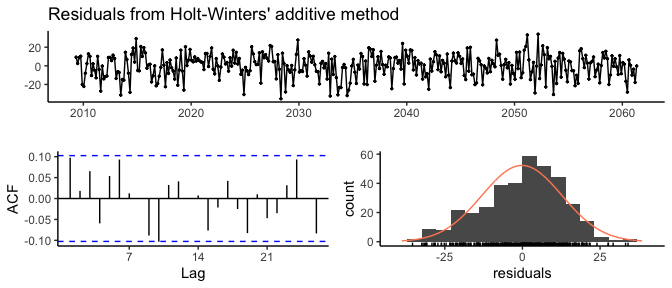

```
#>
#>  Ljung-Box test
#>
#> data:  Residuals from Holt-Winters' additive method
#> Q* = 18.934, df = 3, p-value = 0.0002822
#>
#> Model df: 11.   Total lags used: 14
```

#### ARIMA

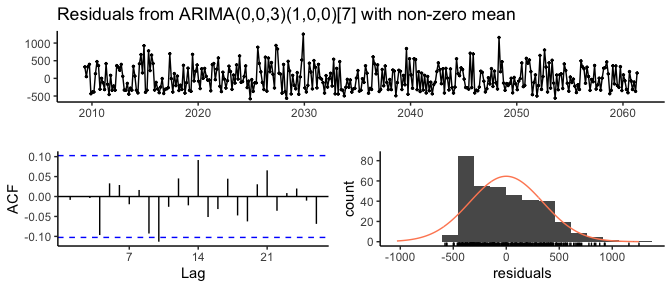

```
#>
#>  Ljung-Box test
#>
#> data:  Residuals from ARIMA(0,0,3)(1,0,0)[7] with non-zero mean
#> Q* = 16.96, df = 9, p-value = 0.04934
#>
#> Model df: 5.   Total lags used: 14
```

This model did fairly well, but it seems like the Holt-Winters with Box-Cox adjustment did better. It’s time to cross-validate and see how all of them preform.

### Cross Validation

Once again, I will use the `tsCV` function and evaluate the models. My goal to minimize the RMSE remains for this dataset.

| Model | RMSE |
| --- | --- |
| ARIMA | 346.7434 |
| STL ARIMA | 353.7169 |
| STL ETS | 366.0626 |
| Adjusted Holt-Winters | 388.4804 |
| Holt-Winters | 504.2440 |

That’s an unexpected result. The Adjusted Holt-Winters (the one I thought would preform the best), did not preform as well. The ARIMA model, once again, rose to the top.

### Model Selection

Once again I will use the forecasts produced by the ARIMA model as the projections for ATM #4.

## Summary

I set out to create predictions for 4 different ATMs. After testing multiple approaches using cross-validation, I selected ARIMA models for ATM #1, #2 and #4, as it was the modeling technique with the lowest RMSE. For ATM #3 we used the mean of all non-zero data (3 observations). This model needs to be updated once more data becomes available. I will finish this project by exporting my forcasts in the same file format as the original data.

## Part B – Forecasting Power, ResidentialCustomerForecastLoad-624.xlsx

[The generated forcates are on Github](https://github.com/salma71/MSDS_spring2021/blob/master/data_624/Residential_Customer_Load_Forecast.xlsx)

Part B consists of a simple dataset of residential power usage for January 1998 until December 2013. Your assignment is to model these data and a monthly forecast for 2014. The data is given in a single file. The variable ‘KWH’ is power consumption in Kilowatt hours, the rest is straight forward. Add this to your existing files above.

## Introduction

I am to forecast how much power will be consumed by residential customers in kilowatt hours for the next 12 months. Data was provided for this project spaning January 1998 until December 2013.

## Data Exploration

I will begin by reading in the data and ploting the series.

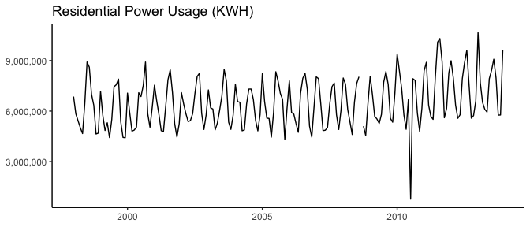

|  | KWH |
| --- | --- |
|  | Min. : 770523 |
|  | 1st Qu.: 5429912 |
|  | Median : 6283324 |
|  | Mean : 6502475 |
|  | 3rd Qu.: 7620524 |
|  | Max. :10655730 |
|  | NA’s :1 |

We have outliers and missing data. We will clean them up with `tsclean` from the forcasts package, and replot the data with the ACF and PACF:

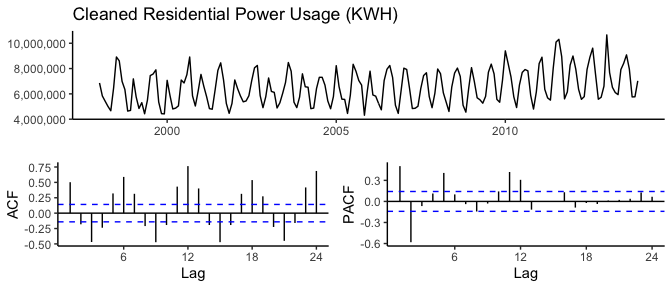

This looks much better. There is a seasonal component that looks to be additive. I will need to use a model that captures seasonality.

## Candidate Models

Since the data is highly seasonal, I we will need to use an ARIMA or Holt-Winters model. Let’s fit an models using `auto.arima()` and `hw()` and visualize their projections. I will use a couple of different parameters with the Holt-Winters model.

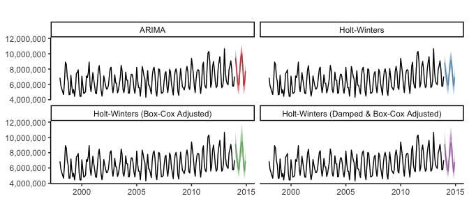

## Residual Analysis

All models do a good job picking up the seasonality. Let’s look at the residuals to see if any of the models should not be used.

### Holt-Winters Model

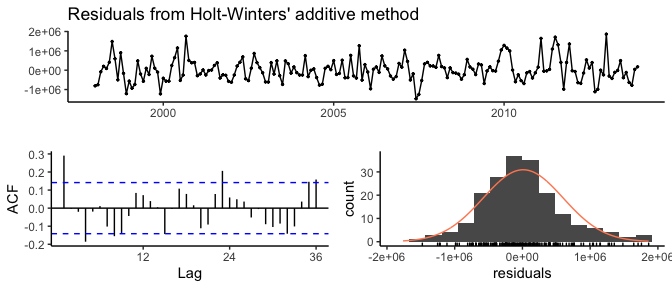

```
#>
#>  Ljung-Box test
#>
#> data:  Residuals from Holt-Winters' additive method
#> Q* = 61.741, df = 8, p-value = 2.121e-10
#>
#> Model df: 16.   Total lags used: 24
```

There are some spikes in the ACF that indicate this is not the best model.

### Adjusted Holt-Winters Model

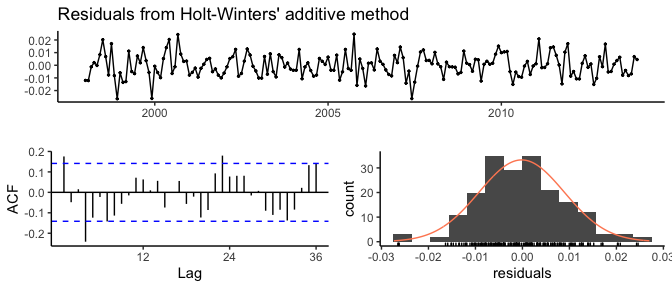

```
#>
#>  Ljung-Box test
#>
#> data:  Residuals from Holt-Winters' additive method
#> Q* = 48.973, df = 8, p-value = 6.433e-08
#>
#> Model df: 16.   Total lags used: 24
```

This is a bit better than the previous model but there are still ACF spikes outside of the bands.